# Session 16 Practice

In this practice, we will analyze various statistics from MBA applicants across 22 different industries. The data is contained in the file "MBA_Stat.csv".

First, read in the data and use the head method to double check that everything has been read in correctly. Make sure to add you "%matplotlib inline" statement at the top of the code block as well importing pandas and matplotlib.pyplot.

```python
%matplotlib inline

#Import here
import pandas as pd
import matplotlib.pyplot as plt

#Set you style if you want
plt.style.use("ggplot")

#Write your code here
df_MBA = pd.read_csv("Data/MBA_Stats.csv", index_col=0)
df_MBA.head()
```

|  | Industry | Avg_GMAT | Avg_Age | Avg_Job_Months |
| --- | --- | --- | --- | --- |
| 0 | Accounting | 657.555379 | 28.445946 | 60.108108 |
| 1 | Advertising/Marketing Services | 633.750000 | 29.625000 | 71.750000 |
| 2 | Aerospace | 674.683303 | 28.635116 | 60.818182 |
| 3 | Agribusiness | 636.666667 | 28.611111 | 52.444444 |
| 4 | Auto/Transportation | 643.480908 | 30.118421 | 69.500000 |

We will begin by creating some basic single plots. First create a scatterplot of Avg. Age vs. Avg. GMAT Score.

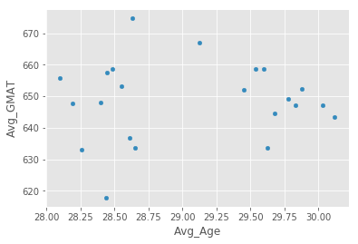

```python
#Create figure and axis
fig,ax = plt.subplots()

#Create your plot here
df_MBA.plot(kind= "scatter", x = "Avg_Age", y = "Avg_GMAT", ax=ax)
```

Next, we would like to create the following two histograms, which give us how the average GMAT and average previous work experience is distributed across industries.

[figure not shown]

First create the 1x2 figure. Use figsize = (10,5). Add the figure title.

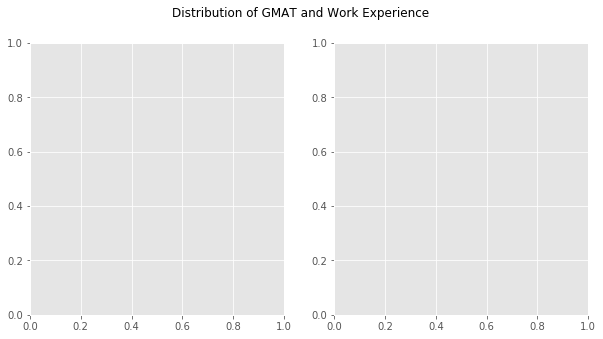

```python
fig, (ax0, ax1) = plt.subplots(nrows=1, ncols=2, figsize = (10,5))

fig.suptitle("Distribution of GMAT and Work Experience")
```

Next create th first histogram on ax0. Vary the bin size so the histogram provides as much information as possible. Also, add the appropriate x-axis title.

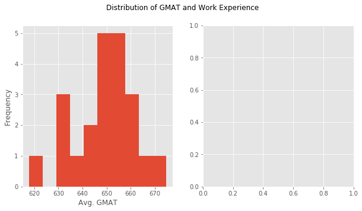

```python
#Create the histogram
df_MBA.Avg_GMAT.plot(kind= "hist", bins=10, ax=ax0)

#Add x-axis title
ax0.set_xlabel("Avg. GMAT")
```

Now add in the vertical dashed average line with the corresponding annotation.

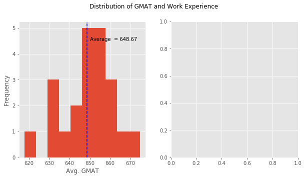

```python
#Add vertical average line
mean_gpa = df_MBA.Avg_GMAT.mean()
ax0.axvline(mean_gpa, color = "b", linestyle = "--")
text = "Average  = %0.2f" %mean_gpa
ax0.annotate(text, xy = (650,4.5))

fig
```

Now create the second histogram for work experience

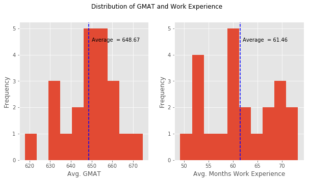

```python
#Write your code here

#Create the histogram
df_MBA.Avg_Job_Months.plot(kind= "hist", bins=10, ax=ax1)

#Add x-axis title
ax1.set_xlabel("Avg. Months Work Experience")

#Add vertical average line
mean_work = df_MBA.Avg_Job_Months.mean()
ax1.axvline(mean_work, color = "b", linestyle = "--")
text = "Average  = %0.2f" %mean_work
ax1.annotate(text, xy = (62,4.5))

fig
```

Now on to the main event.

[figure not shown]

Create a 1X3 figure with a shared y axis and three axes. Set figsize = (10,10). Add the figure title to the figure.

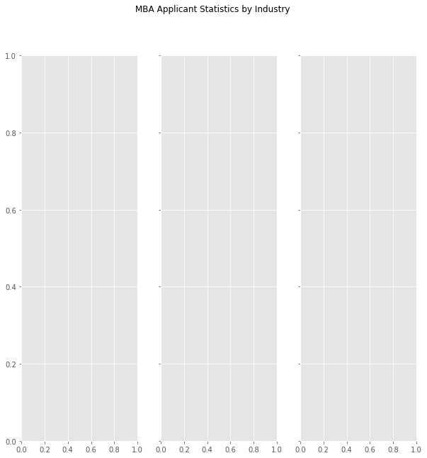

```python
#Write your code here
fig, (ax0,ax1,ax2) = plt.subplots(nrows=1, ncols=3, sharey=True, figsize = (10,10))

fig.suptitle("MBA Applicant Statistics by Industry")
```

Create the plot on ax0, you should set kind = "barh". Add the appropriate titles and axes labels.

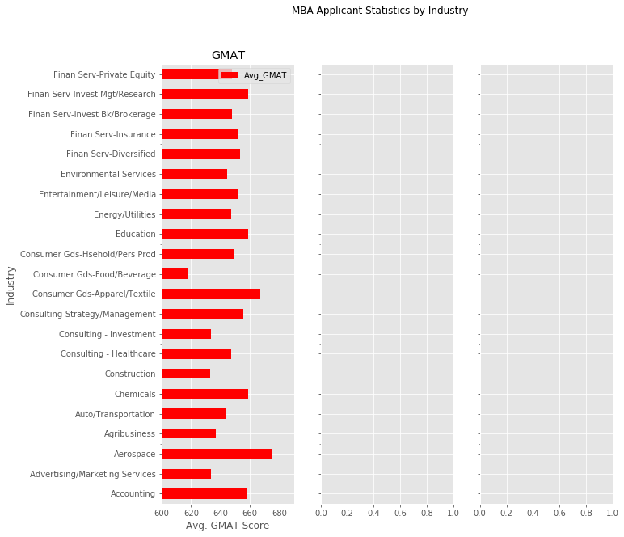

```python
#Add the plot
df_MBA.plot(kind= "barh", x = "Industry", y = "Avg_GMAT", color="r", ax=ax0)

#Update axes features.  Make the x axis go from 600 to 690.
ax0.set(title = "GMAT", xlabel="Avg. GMAT Score", ylabel= "Industry")
ax0.set_xlim([600,690])

fig
```

Create the plot of ax1.

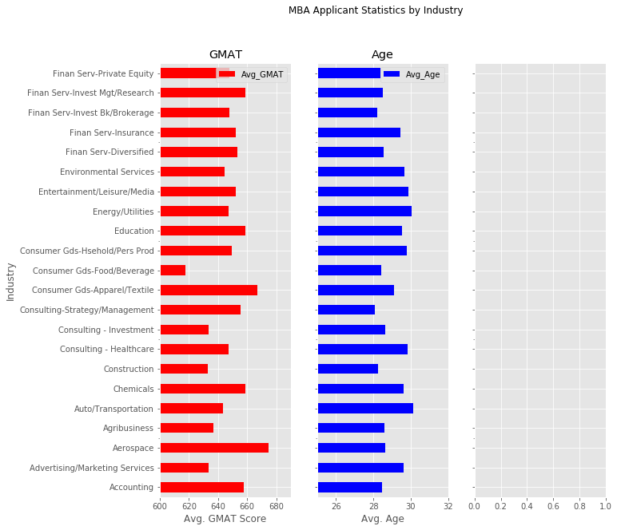

```python
#Add the plot
df_MBA.plot(kind= "barh", x = "Industry", y = "Avg_Age", color= "b", ax=ax1)

#Update axes features.  Make the x axis go from  25 to 32.
ax1.set(title = "Age", xlabel="Avg. Age",ylabel= "Industry")
ax1.set_xlim([25,32])

fig
```

Create the plot of ax2.

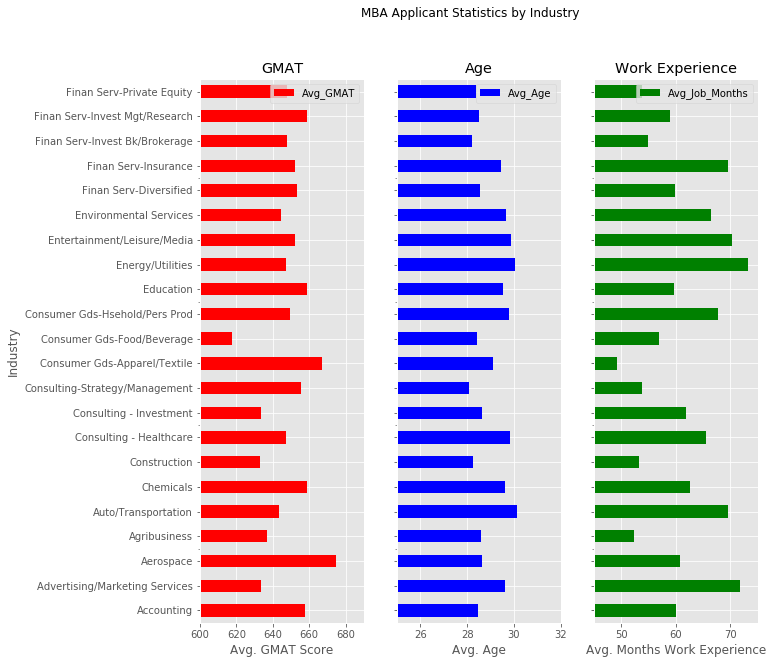

```python
#Add the plot
df_MBA.plot(kind= "barh", x = "Industry", y = "Avg_Job_Months", color= "g", ax=ax2)

#Update axes features.  Make the x axis go from  45 to 75.
ax2.set(title = "Work Experience", xlabel="Avg. Months Work Experience")
ax2.set_xlim([45,75])

fig
```